# Lei de Okun

Lucas Mendes

31/05/2020

## Introdução

A lei de Okun é uma equação que relaciona o hiato do produto com o hiato do desemprego. Em teoria, essa relação deve ser negativa, ou seja, caso o país passe por um um hiato positivo (PIB Real maior que o PIB Potencial), o hiato do desemprego deve ser negativo (Desemprego Real menor que o Desemprego Natural). Vamos verificar na prática essa relação?

## Especificação

$$U_{t} = \alpha + \beta(Y_{t} - Y^*_{t})$$

$U_{t}$ = Desemprego no mês t

$\alpha$ = Intercepto Linear

$Y_{t}$ = PIB no mês t

$Y^*_{t}$ = PIB potencial no mês t

## Pacotes necessários

```r
# install.packages("tidyverse")
# install.packages("deflateBR")
# install.packages("devtools")
# install.packages("mFilter")
# devtools::install.github("wilsonfreitas/rbcb")
# install.packages("stargazer")

library(tidyverse) # Melhor pacote do R
library(deflateBR) # Deflacionar séries
library(rbcb) # Pegar dados do banco central
library(mFilter) # Pegar tendencia
library(stargazer) # Tabelas de regressão
```

## Coleta dos dados

Para coletar os dados iremos usar o pacote rbcb, especificamente a função get_series()

```r
PIB <- get_series(c("Produto" = 4380), # Número da série no banco central
                  start_date = "2012-03-01",# Data inicial
                  end_date = "2019-12-01",# Data final
                  as = "tibble") # Formato retornado

Desemprego <- get_series(c("PNADc" = 24369), # Número da série no banco central
                  start_date = "2012-03-01",# Data inicial
                  end_date = "2019-12-01", # Data final
                  as = "tibble") # Formato retornado
```

## Visualizando as séries

### PIB

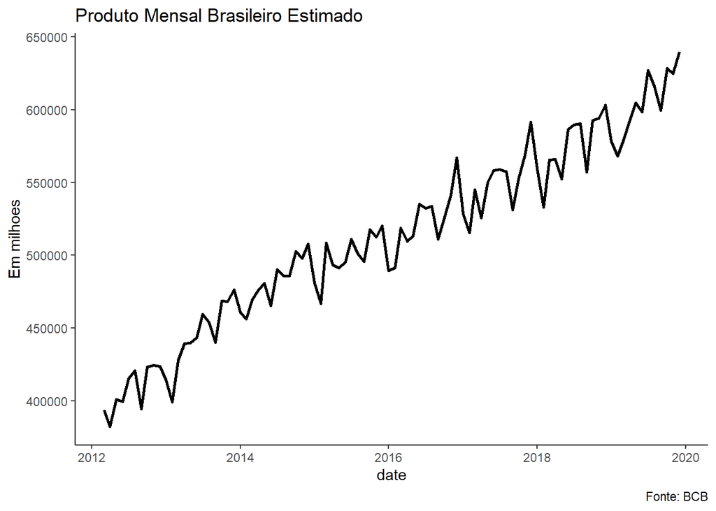

```r
PIB %>% ggplot(aes(date,Produto)) +
  geom_line(size = 1) +
  labs(title = "Produto Mensal Brasileiro Estimado",
       caption = "Fonte: BCB",
       y = "Em milhoes") +
  theme_classic()
```

### Desemprego

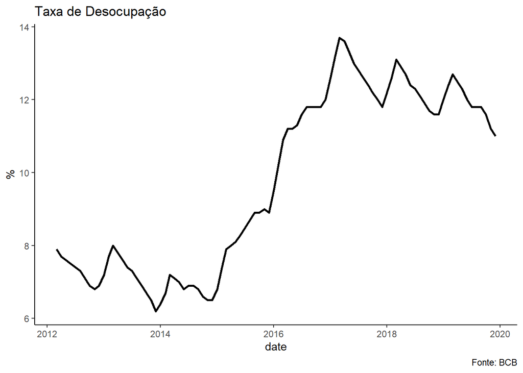

```r
Desemprego %>% ggplot(aes(date,PNADc)) +
  geom_line(size = 1) +
  labs(title = "Taxa de Desocupação",
       caption = "Fonte: BCB",
       y = "%") +
  theme_classic()
```

## Deflacionando o PIB

Como podemos notar, nossa série de PIB não está deflacionada, parece até que nunca tivemos uma crise. Para realizar essa operação, iremos usar a função deflate do pacote deflateBR.

```r
PIB <- PIB %>%
  mutate(Produto_deflacionado = deflate(Produto,date,"03/2012"))
```

Observando novamente o gráfico do produto

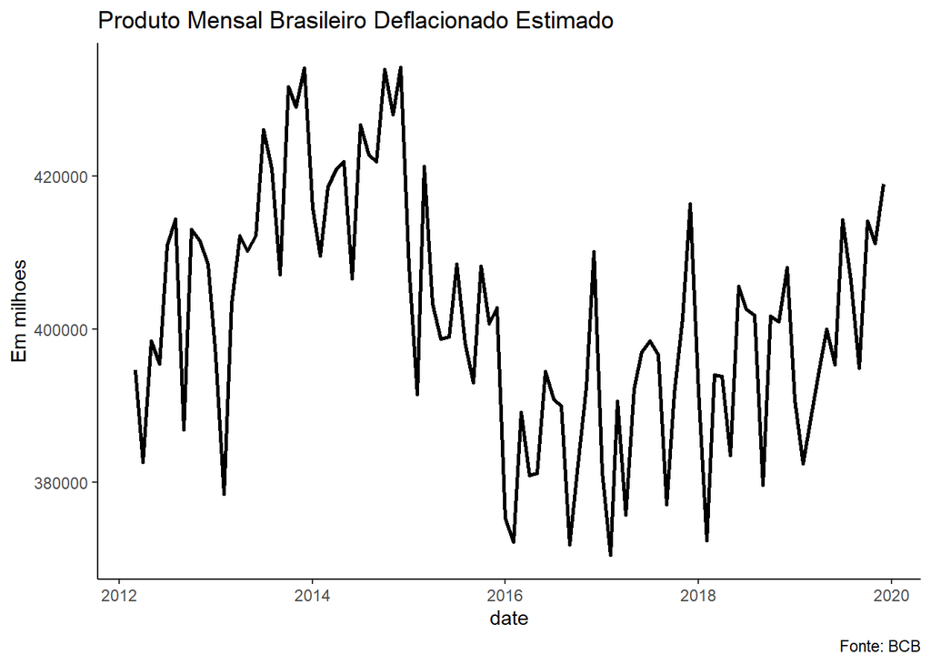

```r
PIB %>% ggplot(aes(date,Produto_deflacionado)) +
  geom_line(size = 1) +
  labs(title = "Produto Mensal Brasileiro Deflacionado Estimado",
       caption = "Fonte: BCB",
       y = "Em milhoes") +
  theme_classic()
```

## Cálculo do Hiato do Produto

Para calcular o hiato do produto iremos usar a função hpFilter, do pacote mFilter. Ela irá aplicar o filtro de Hodrick-Prescott para a nossa série de PIB. O objeto retornado é um objeto um pouco estranho, então busque saber como fazer o slice corretamente

```r
hp_pib <- hpfilter(PIB$Produto_deflacionado,freq = 1600)

hp_pib$trend <- hp_pib$trend %>% t() %>% as.vector()

PIB <- PIB %>%
  mutate(Hiato_Produto = (hp_pib$cycle/hp_pib$trend)*100)
```

## Formatando nossa base de dados

Com as transformações feitas, iremos agora agregar em um novo data frame a nossa base de dados

```r
dados <- Desemprego %>%
  left_join(PIB %>% select(date,Hiato_Produto))
```

## Regressão

Primeiro iremos observar a relação entre o Hiato do Produto e a taxa de desemprego

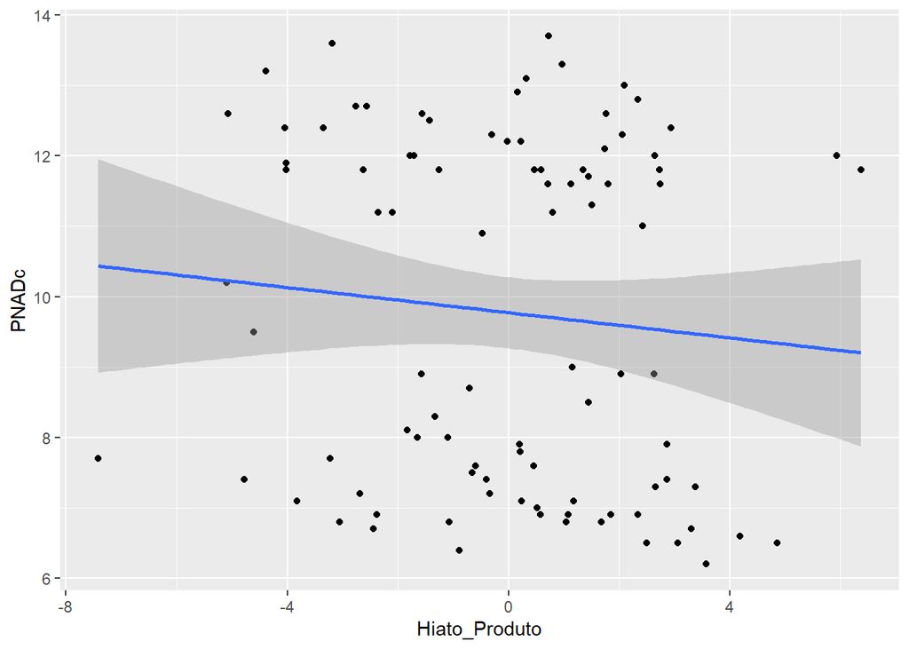

```r
dados %>%
  ggplot(aes(x = Hiato_Produto,y = PNADc)) +
  geom_point() +
  geom_smooth(method = "lm")
```

Vemos que há uma relação negativa entra as variáveis, porém os dados encontram - se muito dispersos.

Montaremos agora nosso modelo usando a função lm(), nativa do R

```r
modelo <- lm(PNADc ~ Hiato_Produto,dados)
```

```r
stargazer(modelo, title="Results",type = 'html',
          style = "aer")
```

**Results**

|  | PNADc |
| --- | --- |
| Hiato_Produto | -0.089 |
|  | (0.097) |
| Constant | 9.774*** |
|  | (0.254) |
| Observations | 94 |
| R<sup>2</sup> | 0.009 |
| Adjusted R<sup>2</sup> | -0.002 |
| Residual Std. Error | 2.465 (df = 92) |
| F Statistic | 0.848 (df = 1; 92) |
| *Notes:* | ***Significant at the 1 percent level. |
|  | **Significant at the 5 percent level. |
|  | *Significant at the 10 percent level. |